# Assessment 3 - Aviv Gelfand

52414

1. Write a function that recieves as input two vectors of real numbers: `a` and `x`. The function should return a vector `e` of the same length as `a`, such that `e_i` is the empirical cumulative distribution function of the sample `x`, evaluated at the point a(i), that is $e_i = \hat{F}_n(a(i))$ where $\hat{F}_n$ is the empirical CDF defined by $x$. Do not use the `ecdf` function of **R**.  
   **Solution:**

```r
my_ecdf <- function(a, x){
  n <- length(x)
  e = sapply(X = a, FUN = sum.cum.ai, n_lentgth = n ,x_vector = x )
  return (e)
}

sum.cum.ai <- function(a.i,n_lentgth, x_vector){
  return(sum(x_vector <= a.i) / n_lentgth)
}



x_test = c(1:10)
a_test = c(10, 3, 8, 20)

sum(x_test <= a_test[2])
```

```
## [1] 3
```

```r
my_ecdf(a_test,x_test)
```

```
## [1] 1.0 0.3 0.8 1.0
```

2. Download from moodle and load the Israeli crime dataset `Israel crime 2011 regions`.  
   Calculate the `assaults-rate:` assaults per 1000 people for each city in the Israeli crime dataset. Make a figure showing the empirical CDF of the assults-rate in each of the four regions in Israel (one plot, 4 different curves of different colors, each representing a different region). You can use the function from question 1 or other commands in R.  
   **Solution:**

```r
library(tidyverse)
library(dslabs)
library(dplyr)



crimes = read.csv("israeli_crime_2011_region.csv",stringsAsFactors = FALSE)  # Set path and read data.
head(crimes, 3)
```

```
##     town region year assaults  total
## 1  AFULA  North 2011      329  53229
## 2   AKKO  North 2011      401  55788
## 3 ASHDOD  South 2011     1171 251343
```

```r
names(crimes)[5] <- "population"
crimes$assaults_rate = (crimes$assaults/crimes$population)*1000
head(crimes,3)
```

```
##     town region year assaults population assaults_rate
## 1  AFULA  North 2011      329      53229      6.180841
## 2   AKKO  North 2011      401      55788      7.187926
## 3 ASHDOD  South 2011     1171     251343      4.658972
```

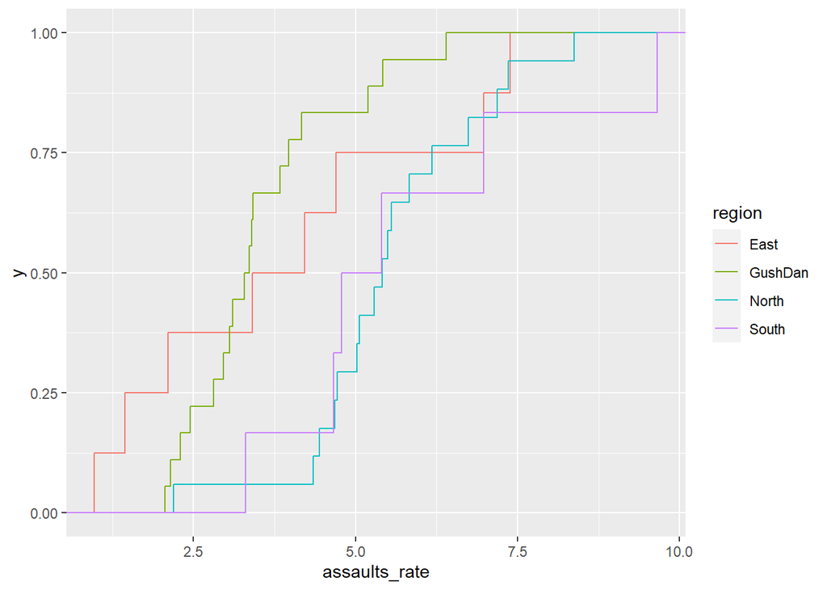

```r
# PLOT
crimes %>% ggplot(aes(x=assaults_rate , col=region)) +
  stat_ecdf()
```

3. Make a figure with histogram plot for the assaults rate in the North region. Choose a bin size approriate for the data.

Next, make another figure with a single smoothed density plot showing the densities of the four regions of the same data as in qu. 2 (with four different colors).

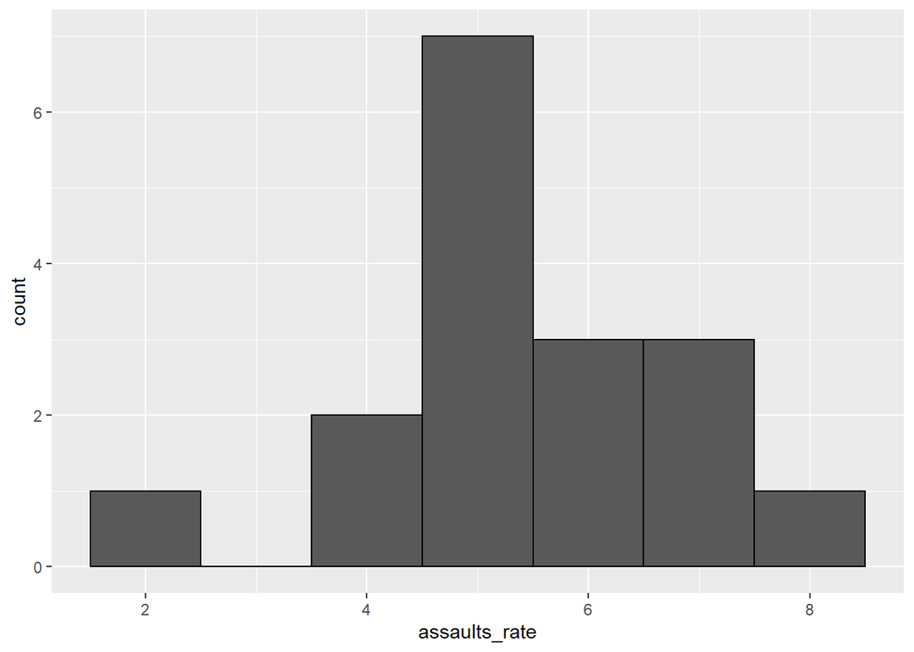

```r
north_crimes = filter(crimes, region == "North")
north_crimes %>% ggplot(aes(assaults_rate)) + geom_histogram(binwidth = 1,color = "black")
```

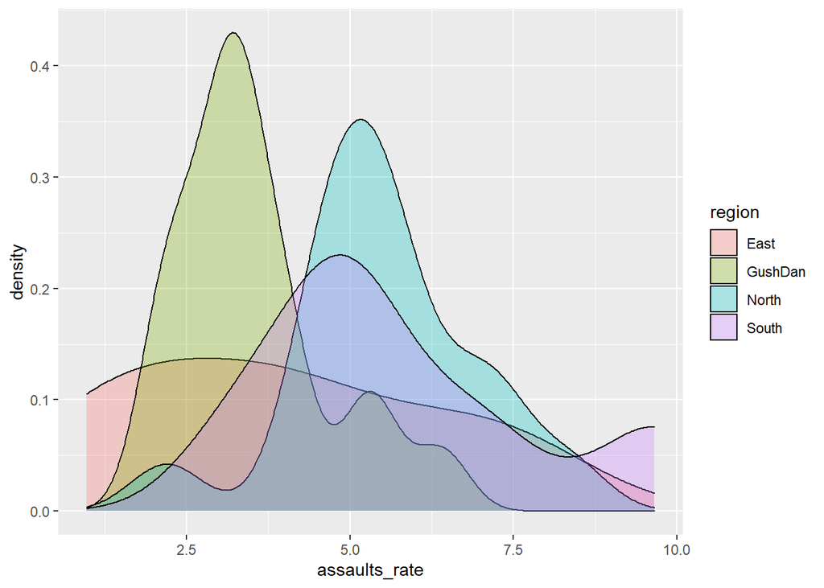

```r
#make another figure with a single smoothed density plot showing the
#densities of the four regions of the same data as in qu. 2 (with four different colors).
crimes %>% ggplot(aes(assaults_rate, fill = region))+
  geom_density(alpha = 0.3)
```